# Using Web APIs in R

July 12, 2017

## Overview

- Quick review of web API basics
- Tools for accessing APIs
- Lots of examples
- Practical application
- What next?

## API Basics

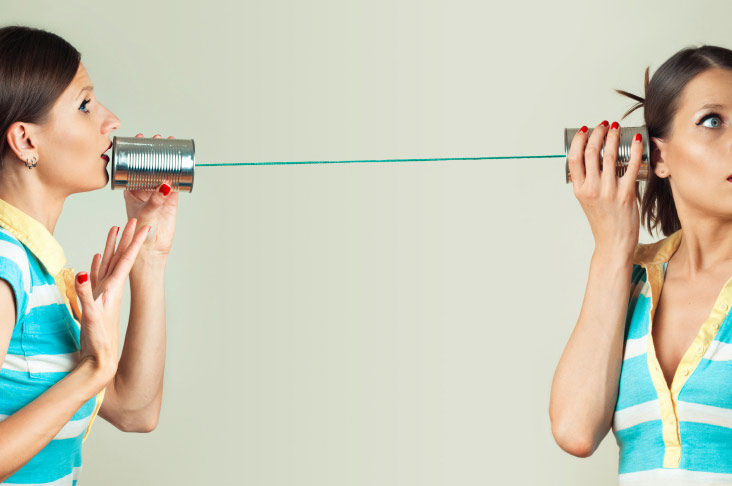

## Client-Server Communication

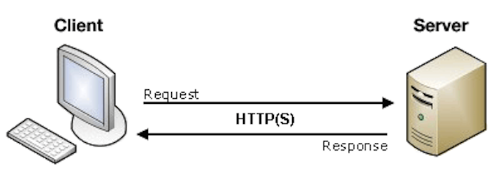

Request:

```
curl "http://www.omdbapi.com/?t=clue&r=json"
```

Response:

```
{"Title":"Clue","Year":"1985","Rated":"PG", ...}
```

## API Resource Map

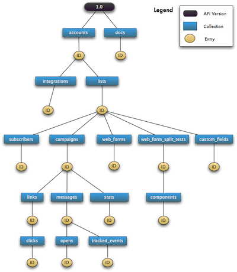

## API Documentation

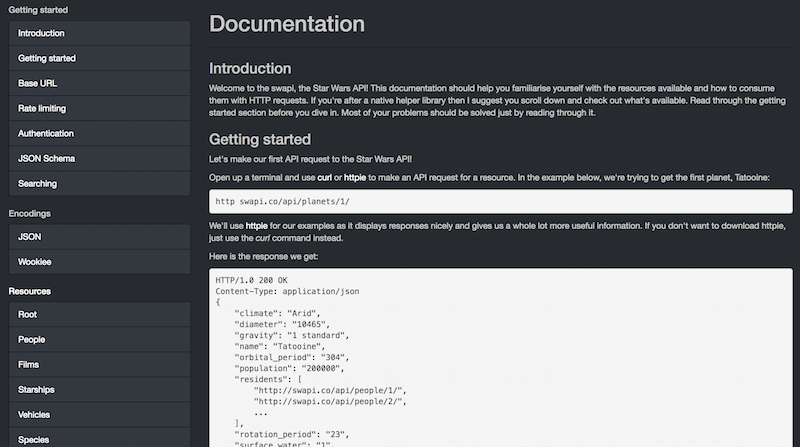

Documentation example: https://swapi.co/documentation

## Tools for accessing web APIs from R

- packages that wrap API calls for a given service
  - aws.s3, RGoogleAnalytics, acs, etc.
- **httr** for making requests
- **jsonlite, xml2** for parsing the response

*And once you have the data…*

- **dplyr, tidyr, lubridate, stringr**, etc. for data wrangling

[figure not shown]

## httr request functions

Wrap (and very conveniently match) HTTP verbs:

`HEAD()`

`GET()`

`POST()`

`PATCH()`

`PUT()`

`DELETE()`

## httr request

To make a request, first load httr, then call GET() with a url:

```r
library(httr)
r <- GET("http://swapi.co/api/planets/1")
```

This gives you a response object:

```r
r
```

```
## Response [http://swapi.co/api/planets/1/]
##   Date: 2017-07-12 14:31
##   Status: 200
##   Content-Type: application/json
##   Size: 805 B
```

## httr response

Use various helpers to dig into the response object:

```r
status_code(r)
```

```
## [1] 200
```

```r
headers(r)
```

```
## $date
## [1] "Wed, 12 Jul 2017 14:31:37 GMT"
##
## $`content-type`
## [1] "application/json"
##
## $`transfer-encoding`
## [1] "chunked"
##
## $connection
## [1] "keep-alive"
##
## $vary
## [1] "Accept, Cookie"
##
## $allow
## [1] "GET, HEAD, OPTIONS"
##
## $`x-frame-options`
## [1] "SAMEORIGIN"
##
## $etag
## [1] "W/\"167b2ef894493c72d59ba5a45bab88cf\""
##
## $via
## [1] "1.1 vegur"
##
## $server
## [1] "cloudflare-nginx"
##
## $`cf-ray`
## [1] "37d4b50ce3d92204-EWR"
##
## $`content-encoding`
## [1] "gzip"
##
## attr(,"class")
## [1] "insensitive" "list"
```

## httr response body

And understand the content of the response:

```r
str(content(r))
```

```
## List of 14
##  $ name           : chr "Tatooine"
##  $ rotation_period: chr "23"
##  $ orbital_period : chr "304"
##  $ diameter       : chr "10465"
##  $ climate        : chr "arid"
##  $ gravity        : chr "1 standard"
##  $ terrain        : chr "desert"
##  $ surface_water  : chr "1"
##  $ population     : chr "200000"
##  $ residents      :List of 10
##   ..$ : chr "http://swapi.co/api/people/1/"
##   ..$ : chr "http://swapi.co/api/people/2/"
##   ..$ : chr "http://swapi.co/api/people/4/"
##   ..$ : chr "http://swapi.co/api/people/6/"
##   ..$ : chr "http://swapi.co/api/people/7/"
##   ..$ : chr "http://swapi.co/api/people/8/"
##   ..$ : chr "http://swapi.co/api/people/9/"
##   ..$ : chr "http://swapi.co/api/people/11/"
##   ..$ : chr "http://swapi.co/api/people/43/"
##   ..$ : chr "http://swapi.co/api/people/62/"
##  $ films          :List of 5
##   ..$ : chr "http://swapi.co/api/films/5/"
##   ..$ : chr "http://swapi.co/api/films/4/"
##   ..$ : chr "http://swapi.co/api/films/6/"
##   ..$ : chr "http://swapi.co/api/films/3/"
##   ..$ : chr "http://swapi.co/api/films/1/"
##  $ created        : chr "2014-12-09T13:50:49.641000Z"
##  $ edited         : chr "2014-12-21T20:48:04.175778Z"
##  $ url            : chr "http://swapi.co/api/planets/1/"
```

## http response components: status

```r
http_status(r)
```

```
## $category
## [1] "Success"
##
## $reason
## [1] "OK"
##
## $message
## [1] "Success: (200) OK"
```

```r
r$status_code
```

```
## [1] 200
```

You can automatically throw a warning or raise an error if a request did not succeed with `warn_for_status(r)` or `stop_for_status(r)`

## http response components: headers

```r
headers(r)
```

```
## $date
## [1] "Wed, 12 Jul 2017 14:31:37 GMT"
##
## $`content-type`
## [1] "application/json"
##
## $`transfer-encoding`
## [1] "chunked"
##
## $connection
## [1] "keep-alive"
##
## $vary
## [1] "Accept, Cookie"
##
## $allow
## [1] "GET, HEAD, OPTIONS"
##
## $`x-frame-options`
## [1] "SAMEORIGIN"
##
## $etag
## [1] "W/\"167b2ef894493c72d59ba5a45bab88cf\""
##
## $via
## [1] "1.1 vegur"
##
## $server
## [1] "cloudflare-nginx"
##
## $`cf-ray`
## [1] "37d4b50ce3d92204-EWR"
##
## $`content-encoding`
## [1] "gzip"
##
## attr(,"class")
## [1] "insensitive" "list"
```

## http response components: cookies

```r
cookies(r)
```

```
##                domain flag path secure          expiration     name
## 1 #HttpOnly_.swapi.co TRUE    /  FALSE 2018-07-12 10:31:37 __cfduid
##                                         value
## 1 df4496a8315f857e1a271134b6690bfb81499869897
```

## http response components: body

```r
content(r, "text")  # character vector
```

`## [1] "{\"name\":\"Tatooine\",\"rotation_period\":\"23\", \"orbital_period\":\"304\",\"diameter\":\"10465\",\"climate\":\"arid\", \"gravity\":\"1 standard\",\"terrain\":\"desert\", \"surface_water\":\"1\",\"population\":\"200000\", \"residents\":[\"http://swapi.co/api/people/1/\", \"http://swapi.co/api/people/2/\",\"http://swapi.co/api/people/4/\", \"http://swapi.co/api/people/6/\",\"http://swapi.co/api/people/7/\", \"http://swapi.co/api/people/8/\",\"http://swapi.co/api/people/9/\", \"http://swapi.co/api/people/11/\",\"http://swapi.co/api/people/43/\", \"http://swapi.co/api/people/62/\"],\"films\":[\"http://swapi.co/api/films/5/\", \"http://swapi.co/api/films/4/\",\"http://swapi.co/api/films/6/\", \"http://swapi.co/api/films/3/\",\"http://swapi.co/api/films/1/\"], \"created\":\"2014-12-09T13:50:49.641000Z\", \"edited\":\"2014-12-21T20:48:04.175778Z\",\"url\":\"http://swapi.co/api/planets/1/\"}"`

## http response components: body

```r
content(r, "raw")  # raw vector, for non-text responses
```

[output not shown]

[output cut: 20 more lines]

## http response components: body

```r
content(r, "parsed")  # default parsers for common file types
```

```
## $name
## [1] "Tatooine"
##
## $rotation_period
## [1] "23"
##
## $orbital_period
## [1] "304"
##
## $diameter
## [1] "10465"
##
## $climate
## [1] "arid"
##
## $gravity
## [1] "1 standard"
##
## $terrain
## [1] "desert"
##
## $surface_water
## [1] "1"
##
## $population
## [1] "200000"
##
## $residents
## $residents[[1]]
## [1] "http://swapi.co/api/people/1/"
##
## $residents[[2]]
## [1] "http://swapi.co/api/people/2/"
##
## $residents[[3]]
## [1] "http://swapi.co/api/people/4/"
##
## $residents[[4]]
## [1] "http://swapi.co/api/people/6/"
##
```

[output cut: 29 more lines]

```
## $films[[4]]
## [1] "http://swapi.co/api/films/3/"
##
## $films[[5]]
## [1] "http://swapi.co/api/films/1/"
##
##
## $created
## [1] "2014-12-09T13:50:49.641000Z"
##
## $edited
## [1] "2014-12-21T20:48:04.175778Z"
##
## $url
## [1] "http://swapi.co/api/planets/1/"
```

## Examples

SWAPI - https://swapi.co/

Twitter (OAuth1) - https://api.twitter.com

GitHub (OAuth2) - https://api.github.com

## Other considerations

- API documentation, honesty, response format
- Paging
- Rate limiting/throttling
- Time to first byte (response time)
- Data storage
- Additional **httr** functionality
  - Authentication
    - `authenticate()`, `oauth1.0_token()`, `oauth2.0_token()`, `use_proxy()`
  - Request modifiers
    - `set_cookies()`, `add_headers()`, `content_type()`, `accept()`
  - Other
    - `stop_for_status()`, `warn_for_status()`, `timeout()`, `verbose()`, `parse_url()`, `progress()`

## Practical application

*Support Ticket Reports, in Two Parts*

1. R script to get support ticket data via API
   - Pages through data and puts it all in a single dataframe
   - Filters, tidies, and flattens the raw data into a nice, easy-to-use rectangle
   - Saves the tidied data to an S3 bucket
   - Deployed to RStudio Connect; scheduled to poll the API and update the datastore automatically
2. Various applications and Rmd documents pull the data from S3
   - Visualizations for tickets by product, OS, priority, category/feature, etc.
   - We use this data to target product improvements, documentation enhancements, process improvements

Support Ticket Demo

## Recap

- APIs are very useful sources of data, especially for datasets that are updated regularly.
- It's easy to pull API data into R – and keep it up-to-date – with the right packages and tools.
- Once you have the data in R, you can do all sorts of wonderful things with it.

## What next?

- More on APIs and HTTP:
  - https://zapier.com/learn/apis/chapter-1-introduction-to-apis/
  - https://www.ntu.edu.sg/home/ehchua/programming/webprogramming/HTTP_Basics.html
- More on the tools:
  - `> help(package=httr)`
  - https://cran.r-project.org/web/packages/httr/vignettes/quickstart.html
  - http://github.com/hadley/httr/tree/master/demo
  - https://cran.r-project.org/web/packages/jsonlite/vignettes/json-apis.html
  - https://cran.r-project.org/web/packages/httr/vignettes/api-packages.html
- amanda@rstudio.com